**In this project I worked on the ImDB**

**In this project, the following questions are answered and visualized**

- What is the most rated movie?
- What is the most voted movie?
- Most successful director?
- Top 3 movies for the top 3 directors?
- Highest movie budget?
- Longest movie runtime?
- Most famous Genres?
- Top Movies for each Genre?
- Most popular movie?
- Does the production of movies increase or decrease?

**To answer the previous questions I extracted the following:**

1. What is the most rated movie? The movie title with a max value of vote_average.
2. What is the most voted movie? The movie title with a max value of vote_count.
3. Most successful director? I used groupby to extract the director with the highest vote_count sum.
4. Top 3 movies for the top 3 directors? I used groupby to extract the movies with each top 3 director.
5. Highest movie runtime? I extracted the movie with the max value of runtime.
6. Highest movie budget? I extracted the movie with the max value of budget.
7. Most famous Genres? I used groupby to sum all the vote_counts of each genre then sorting them.
8. Top movies for each Genre? I extracted the max value of vote_count of each movie for each genre.
9. Most popular movie? I searched for the movie with the max value of popularity.
10. Does the production of movies increase or decrease? I visualized the previous question by plotting the year and the coressponding total year movie counts.

**The following are the answers to each question**

1. the top rated movie is "The Story of Film: An Odyssey" with an average vote of 9.2
2. "inception" is the top voted movie with a vote count of 9767
3. "Christopher Nolan" is the most famous director as he has a total vote count of 41759
4. For "Christopher Nolan" his top 3 movies are the following:
- The Dark Knight with rating of 8.1
- Interstellar with rating of 8.0
- Inception with rating of 7.9

For "Steven Spielberg" his top 3 movies are the following:

- Schindler's List with rating of 8.1
- Saving Private Ryan with rating of 7.7
- Catch Me If You Can with rating of 7.6

For "Peter Jackson" his top 3 movies are the following:

- The Lord of the Rings: The Return of the King with rating of 7.9
- The Lord of the Rings: The Fellowship of the Ring with rating of 7.8
- The Lord of the Rings: The Two Towers with rating of 7.8
1. "Pirates of the Caribbean: On Stranger Tides" with a budget of 380,000,000$
2. "The Story of Film: An Odyssey" with a runtime of 15 hours.
3. "Comedy" is the most Genre as it has a total vote count of 100806, then followed by "Drama" with a total vote count of 97204

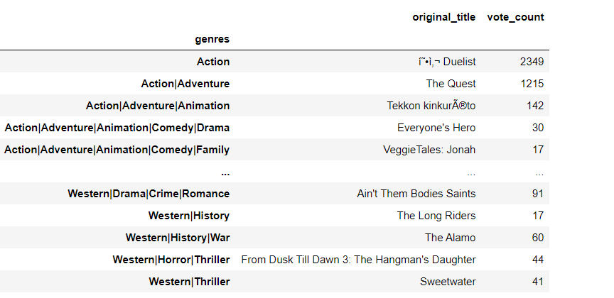

1. "Jurassic World" with a popularity rating of 32.98
1. Movie production is increasing

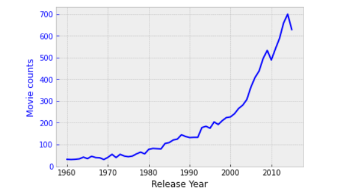